# Optimality criterion with HMSC

Do the Fisher approximations match what HMSC actually learns?

Authors

Affiliations

Loïc Lehnhoff

UMR CESCO

Karine Princé

UMR CESCO

Nicolas Parisey

UMR IGEPP

Published

2026-10-23

# 1 What this document checks

Are the criteria computed with the Fisher approximations close to the criteria measured on the posterior of the HMSC model, refitted on the designs chosen from the approximations?

In this document, we will consider multi-species presence-absence data with residual associations with the following workflow:

1. Simulation:
   - 2 covariates.
   - 2 latent factors.
   - 5 species whose presence depends on the covariates and latent factors.
2. Initial model: HMSC is fitted a first time on existing observation sites (“BIODICAPT” sites in our study).
3. Using five strategies (random-sampling, gap-filling, max-uncertainty, greedy-Ds-optimality and greedy-I-optimality) choose 50 of the 500 candidate sites (“500 ENI”).
4. For each design:
   - 1. the optimality criterion is computed using the approximation formula ($M_j = X^\top (W_j^{-1} + G_j)^{-1} X$).
   - The model is fitted again, but on the new design.
   - 2. Compute the realised criteria, obtained from the posterior of the refitted HMSC.
5. Compare (a) and (b).

# 2 Simulated world

## 2.1 Settings

```r
library(Hmsc)
library(coda)

set.seed(42)

S        <- 5        # number of species
n_cand   <- 500      # candidate sites (500 ENI)
n_select <- 50       # budget (10 % of the candidates)
n_random <- 1        # number of random designs (each one needs an HMSC refit)
n_lf     <- 2        # true number of latent factors
idx_s    <- 2        # parameter of interest: x1 (column 2 of the design matrix)
n_per_cluster <- 25  # existing design: number of obs per cluster (5 clusters)

# HMSC MCMC settings (increase for real work)
mcmc <- list(thin = 5, samples = 500, transient = 1500, nChains = 3)
```

## 2.2 Environment, existing and candidate sites

```r
# environmental fields over the unit square
x1_field <- function(u, v) 3 * (u - 0.5) + 0.4 * sin(2 * pi * v) # west-east gradient
x2_field <- function(u, v) 2 * (v - 0.5) + 1.2 * (u - 0.5) # partly confounded with x1
design_matrix <- function(u, v) cbind("(Intercept)" = 1, x1 = x1_field(u, v), x2 = x2_field(u, v))

# candidate sites: uniformly distributed
cand   <- data.frame(u = runif(n_cand), v = runif(n_cand))
X_cand <- design_matrix(cand$u, cand$v)
centres <- data.frame(u = c(0.15, 0.80, 0.45, 0.20, 0.65),
                      v = c(0.20, 0.15, 0.50, 0.45, 0.90))
n_ref <- nrow(centres) * n_per_cluster
ref   <- data.frame(
  u = pmin(pmax(rep(centres$u, each = n_per_cluster) + rnorm(n_ref, sd = 0.04), 0), 1),
  v = pmin(pmax(rep(centres$v, each = n_per_cluster) + rnorm(n_ref, sd = 0.04), 0), 1))
X_ref <- design_matrix(ref$u, ref$v)

# prediction region: a regular grid on the square (used for the I-criterion)
g_test <- seq(0, 1, length.out = 30)
test   <- expand.grid(u = g_test, v = g_test)
X_test <- design_matrix(test$u, test$v)

# moment matrix of the prediction region, on the linear-predictor scale
B_test <- crossprod(X_test) / nrow(X_test)
```

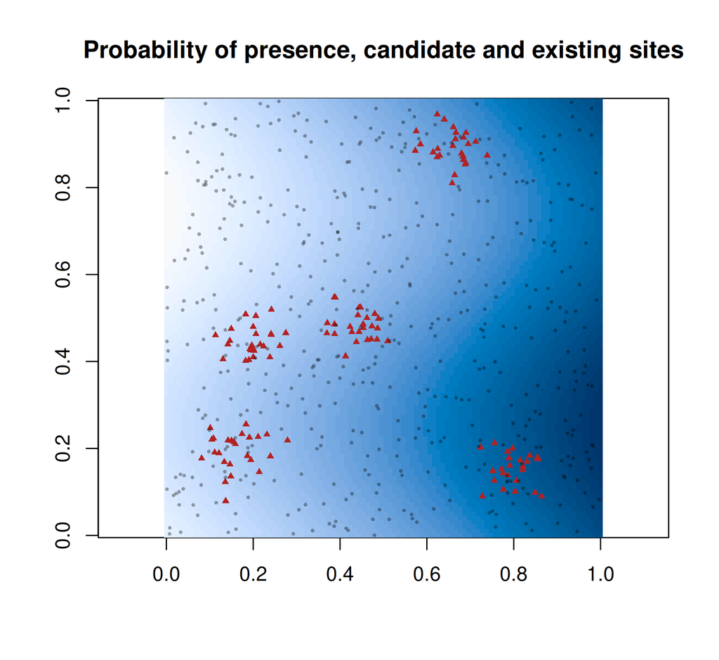

## 2.3 True species responses and simulated observations

Each species has its own $\beta_j$, and species share two latent factors (residual associations). Observations are simulated from the HMSC probit model itself, so that the true parameters live on the same scale as the HMSC estimates (residual variance fixed to 1).

The observations are simulated **once** for all existing and candidate sites: every design then picks a subset of the same “real world” data.

```r
sp_names  <- sprintf("sp%02d", seq_len(S))
beta_true <- rbind("(Intercept)" = rnorm(S, -0.2, 0.4),
                   x1            = rnorm(S,  0.7, 0.5),
                   x2            = rnorm(S,  0.3, 0.4))
colnames(beta_true) <- sp_names
lambda_true <- matrix(rnorm(n_lf * S, 0, 0.7), n_lf, S, dimnames = list(NULL, sp_names))

X_all <- rbind(X_ref, X_cand)
repeat {   # re-draw the noise until every species is observed (present and absent) in the existing sites
  eta_lat <- matrix(rnorm(nrow(X_all) * n_lf), ncol = n_lf)
  Z       <- X_all %*% beta_true + eta_lat %*% lambda_true +
             matrix(rnorm(nrow(X_all) * S), ncol = S)
  Y_all   <- (Z > 0) * 1
  colnames(Y_all) <- sp_names
  Y_ref   <- Y_all[seq_len(n_ref), ]
  if (all(colSums(Y_ref) >= 3 & colSums(Y_ref) <= n_ref - 3)) break
}
Y_cand <- Y_all[-seq_len(n_ref), ]

round(rbind(prevalence_existing   = colMeans(Y_ref),
            prevalence_candidates = colMeans(Y_cand)), 2)
```

```
                      sp01 sp02 sp03 sp04 sp05
prevalence_existing   0.26 0.23 0.43 0.42 0.22
prevalence_candidates 0.29 0.27 0.43 0.47 0.26
```

### 2.3.1 Species distributions

True probability of presence of each species from the fixed effects, $\Phi(x^\top\beta_j)$, with the observations at the existing sites on top. (Actual presences are also affected by the latent factors, so a species can be observed where the map is pale, and vice versa.)

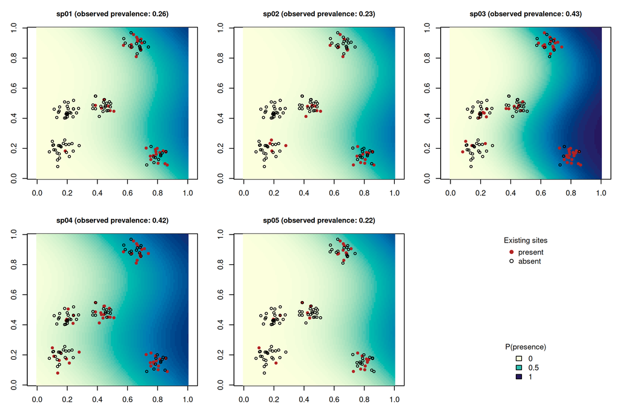

```r
g_map    <- seq(0, 1, length.out = 100)
grid_map <- expand.grid(u = g_map, v = g_map)     # u varies fastest -> matrix(nrow = length(g_map))
X_map    <- design_matrix(grid_map$u, grid_map$v)
eta_map  <- X_map %*% beta_true                   # (100*100) x S
pal      <- hcl.colors(50, "YlGnBu", rev = TRUE)  # light = rare, dark = likely

par(mfrow = c(ceiling((S + 1) / 3), 3), mar = c(3, 3, 3, 1))
for (j in seq_len(S)) {
  p_map <- matrix(pnorm(eta_map[, j]), length(g_map), length(g_map))
  image(g_map, g_map, p_map, col = pal, zlim = c(0, 1), asp = 1, xlab = "", ylab = "",
        main = sprintf("%s (observed prevalence: %.2f)", sp_names[j], mean(Y_ref[, j])),
        cex.main = 0.95)
  present <- Y_ref[, j] == 1
  points(ref$u[present],  ref$v[present],  pch = 19, cex = 0.7, col = "firebrick")
  points(ref$u[!present], ref$v[!present], pch = 1,  cex = 0.7, col = "black")
}

# last panel: legend
plot.new()
legend("top", bty = "n", title = "Existing sites",
       legend = c("present", "absent"), pch = c(19, 1), col = c("firebrick", "black"))
legend("bottom", bty = "n", title = "P(presence)",
       legend = c("0", "0.5", "1"), fill = pal[c(1, 25, 50)])
```

# 3 HMSC wrapper

`fit_hmsc()` fits a probit HMSC model with one site-level (non-spatial) random effect, i.e. $K_{lh} = I$. The covariates are **not** rescaled (`XScale = FALSE`) so that the posterior of $\beta$ is on the same scale as our design matrix.

This function returns what the criteria need: the posterior draws of $\beta_j$, their mean, and $\hat g_j = \sum_h \mathbb E(\lambda_{hj}^2)$.

```r
fit_hmsc <- function(Y, X, keep_model = FALSE) {
  n      <- nrow(Y)
  units  <- sprintf("site%03d", seq_len(n))
  sdes   <- data.frame(site = factor(units))
  rL     <- setPriors(HmscRandomLevel(units = units), nfMax = 4)
  m <- Hmsc(Y = Y,
            XData = data.frame(x1 = X[, "x1"], x2 = X[, "x2"]),
            XFormula = ~ x1 + x2, XScale = FALSE,
            studyDesign = sdes, ranLevels = list(site = rL),
            distr = "probit")
  m <- sampleMcmc(m, thin = mcmc$thin, samples = mcmc$samples,
                  transient = mcmc$transient, nChains = mcmc$nChains, nParallel = mcmc$nChains, verbose = 0)

  post <- poolMcmcChains(m$postList)
  nd   <- length(post)
  Bd   <- array(NA_real_, c(nd, ncol(X), ncol(Y)),
                dimnames = list(NULL, colnames(X), colnames(Y)))
  gd   <- matrix(NA_real_, nd, ncol(Y))
  for (d in seq_len(nd)) {
    Bd[d, , ] <- post[[d]]$Beta
    gd[d, ]   <- colSums(matrix(post[[d]]$Lambda[[1]], ncol = ncol(Y))^2)
  }
  out <- list(beta_draws = Bd,
              beta_mean  = apply(Bd, c(2, 3), mean),
              g          = colMeans(gd))
  if (keep_model) out$model <- m
  out
}
```

## 3.1 Reference model (BIODICAPT only) and planning values

```r
set.seed(1)
base <- fit_hmsc(Y_ref, X_ref, keep_model = TRUE)

# convergence diagnostics for the reference model
cd   <- convertToCodaObject(base$model)
psrf <- gelman.diag(cd$Beta, multivariate = FALSE)$psrf[, 1]
ess  <- effectiveSize(cd$Beta)
rbind(psrf = summary(psrf), ESS = summary(ess))
```

```
            Min.    1st Qu.     Median       Mean     3rd Qu.        Max.
psrf   0.9994481   1.002477   1.005899   1.011315    1.014097    1.044587
ESS  439.3936136 754.288644 973.784734 966.689181 1202.923928 1500.000000
```

```r
# planning values = posterior means of the reference model
beta_hat <- base$beta_mean           # p x S
g_hat    <- base$g                   # S  (diagonal of G_j: sum_h E(lambda_hj^2))

round(rbind(true = colSums(lambda_true^2), estimated = g_hat), 2)
```

```
          sp01 sp02 sp03 sp04 sp05
true      0.21 0.82 1.23 0.48 0.92
estimated 0.07 0.15 0.09 0.31 0.12
```

```r
round(cbind(beta1_true = beta_true["x1", ], beta1_hat = beta_hat["x1", ]), 2)
```

```
     beta1_true beta1_hat
sp01       0.85      0.99
sp02       0.91      0.76
sp03       1.35      0.95
sp04       0.78      0.47
sp05       0.80      0.56
```

# 4 Fisher approximations

For each species $j$, the working model has noise variance $1/w_{ij}$ plus a random-effect variance $g_j$ (independent sites, so $K = I$ and $k = 0$). The effective weight of a site is therefore

$$w^{\text{eff}}_{ij} = \frac{1}{\frac{1}{w_{ij}} + \hat g_j}, \qquad M_j = X^\top \operatorname{diag}(w^{\text{eff}}_{\cdot j})\, X .$$

```r
probit_weights <- function(eta, eps = 1e-8) {
  p <- pmin(pmax(pnorm(eta), eps), 1 - eps)
  dnorm(eta)^2 / (p * (1 - p))
}

# effective weights (n x S) from the planning values
w_eff <- function(X) {
  eta <- X %*% beta_hat
  w   <- matrix(probit_weights(eta), nrow(X), S)
  1 / (1 / w + matrix(g_hat, nrow(X), S, byrow = TRUE))
}
W_ref  <- w_eff(X_ref)
W_cand <- w_eff(X_cand)
M_ref  <- lapply(seq_len(S), function(j) crossprod(X_ref, X_ref * W_ref[, j]))

eta_test_plan <- X_test %*% beta_hat

# Ds-criterion of one information matrix: log det of the Schur complement
ds_logdet <- function(M, idx_s) {
  Sch <- M[idx_s, idx_s, drop = FALSE] -
    M[idx_s, -idx_s, drop = FALSE] %*%
    solve(M[-idx_s, -idx_s, drop = FALSE], M[-idx_s, idx_s, drop = FALSE])
  as.numeric(determinant(Sch, logarithm = TRUE)$modulus)
}

# approximated metrics (per species) of the design "existing + sel"
approx_metrics <- function(sel) {
  sapply(seq_len(S), function(j) {
    M <- M_ref[[j]]
    if (length(sel) > 0) {
      Xs <- X_cand[sel, , drop = FALSE]
      M  <- M + crossprod(Xs, Xs * W_cand[sel, j])
    }
    C <- solve(M)
    c(Ds      = ds_logdet(M, idx_s),
      I       = sum(diag(C %*% B_test)),
      sd_b1   = sqrt(C[idx_s, idx_s]),
      sd_pred = mean(dnorm(eta_test_plan[, j]) * sqrt(rowSums((X_test %*% C) * X_test))))
  })   # 4 x S
}
```

Sanity check of the closed-form gains (one species, one candidate): the gain announced by the Sherman–Morrison formulas must equal the difference of the criteria obtained by actually adding the site to $M$.

```r
j <- 1; c1 <- 1
x <- X_cand[c1, ]; w <- W_cand[c1, j]; M <- M_ref[[j]]
Minv <- solve(M); a <- Minv %*% x
q    <- 1 / w + sum(x * a)
M2   <- M + w * tcrossprod(x)

ds_formula <- -log(1 - (a[idx_s]^2 / Minv[idx_s, idx_s]) / q)
ds_direct  <- ds_logdet(M2, idx_s) - ds_logdet(M, idx_s)
i_formula  <- as.numeric(t(a) %*% B_test %*% a) / q
i_direct   <- sum(diag(solve(M, B_test))) - sum(diag(solve(M2, B_test)))

stopifnot(isTRUE(all.equal(ds_formula, ds_direct)),
          isTRUE(all.equal(i_formula, i_direct)))
c(Ds_formula = ds_formula, Ds_direct = ds_direct, I_formula = i_formula, I_direct = i_direct)
```

```
 Ds_formula   Ds_direct   I_formula    I_direct
0.035174366 0.035174366 0.001173751 0.001173751
```

# 5 The strategies

The two greedy strategies score all candidates for every species with the closed-form gains, **sum the gains over species**, add the best candidate, update each $M_j$, and repeat. HMSC is never refitted during selection.

```r
# 2. gap-filling (farthest-point sampling, relative to the existing sites)
gap_filling <- function(coords, coords_ref, n_select) {
  d_cand <- as.matrix(dist(coords))
  d_ref  <- as.matrix(dist(rbind(coords_ref, coords)))[-seq_len(nrow(coords_ref)),
                                                     seq_len(nrow(coords_ref))]
  min_d <- apply(d_ref, 1, min)
  sel <- integer(0)
  for (k in seq_len(n_select)) {
    nxt   <- which.max(min_d)
    sel   <- c(sel, nxt)
    min_d <- pmin(min_d, d_cand[nxt, ])
  }
  sel
}

# 3. max uncertainty: candidates where the *reference HMSC posterior* is the most variable
#    (posterior SD of the fixed-effect probability, averaged over species; one shot, no refit)
sd_post_cand <- rowMeans(sapply(seq_len(S), function(j) {
  P <- pnorm(X_cand %*% t(base$beta_draws[, , j]))
  sqrt(pmax(rowMeans(P^2) - rowMeans(P)^2, 0))
}))

# 4-5. greedy selection with closed-form gains, summed over species
greedy <- function(criterion = c("Ds", "I"), n_select) {
  criterion <- match.arg(criterion)
  M    <- M_ref
  left <- seq_len(n_cand)
  sel  <- integer(0)
  for (k in seq_len(n_select)) {
    Xl   <- X_cand[left, , drop = FALSE]
    gain <- numeric(length(left))
    for (j in seq_len(S)) {
      Minv <- solve(M[[j]])
      A    <- Minv %*% t(Xl)                                # p x m
      q    <- 1 / W_cand[left, j] + colSums(t(Xl) * A)
      if (criterion == "Ds") {
        Sj   <- solve(Minv[idx_s, idx_s, drop = FALSE])     # M_{1|2}
        aS   <- A[idx_s, , drop = FALSE]
        gain <- gain - log(1 - colSums(aS * (Sj %*% aS)) / q)
      } else {
        gain <- gain + colSums(A * (B_test %*% A)) / q
      }
    }
    best <- left[which.max(gain)]
    for (j in seq_len(S)) M[[j]] <- M[[j]] + W_cand[best, j] * tcrossprod(X_cand[best, ])
    sel  <- c(sel, best)
    left <- setdiff(left, best)
  }
  sel
}

sel_gap    <- gap_filling(cand[, c("u", "v")], ref[, c("u", "v")], n_select)
sel_uncert <- order(sd_post_cand, decreasing = TRUE)[seq_len(n_select)]
sel_ds     <- greedy("Ds", n_select)
sel_i      <- greedy("I",  n_select)

designs <- c(list("Gap-filling" = sel_gap, "Max uncertainty" = sel_uncert,
                  "Greedy Ds" = sel_ds, "Greedy I" = sel_i),
             setNames(replicate(n_random, sample(n_cand, n_select), simplify = FALSE),
                      sprintf("Random %02d", seq_len(n_random))))
```

## 5.1 Where do the strategies put the new sites?

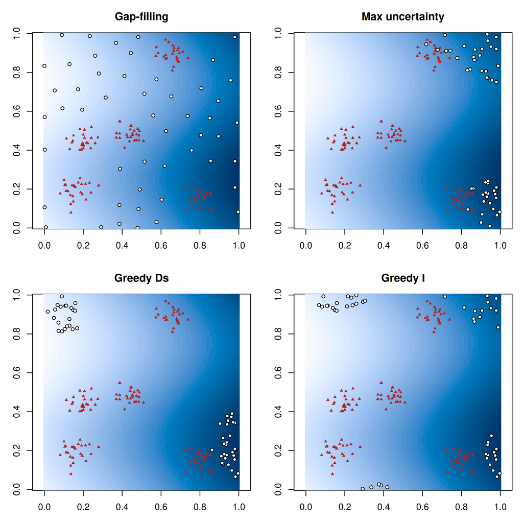

```r
g_map <- seq(0, 1, length.out = 100)
x1_map <- outer(g_map, g_map, x1_field)
par(mfrow = c(2, 2), mar = c(3, 3, 3, 1))
for (nm in c("Gap-filling", "Max uncertainty", "Greedy Ds", "Greedy I")) {
  image(g_map, g_map, x1_map, col = hcl.colors(50, "Blues 3", rev = TRUE), asp = 1,
        xlab = "", ylab = "", main = nm)
  points(ref$u, ref$v, pch = 17, cex = 0.6, col = "firebrick")
  points(cand$u[designs[[nm]]], cand$v[designs[[nm]]], pch = 21, bg = "white", cex = 0.8)
}
```

Background: the covariate $x_1$ (darker = higher). Red triangles are the existing sites, white circles the 50 selected sites.

# 6 Realised criteria from HMSC

For every design, HMSC is refitted on the existing + selected sites with the **same observations** that the design would have collected. The realised analogues of the criteria are computed from the posterior draws, per species $j$:

- $\widehat\Psi_{D_s,j} = -\log\det\widehat{\operatorname{Cov}}_{\text{post}}(\beta_{S,j})$ (here $s=1$: minus the log posterior variance of the $x_1$ effect),
- $\widehat I_j = \operatorname{tr}\bigl(\widehat{\operatorname{Cov}}_{\text{post}}(\beta_j)\,B\bigr)$, the posterior variance of $x_g^\top\beta_j$ averaged over the grid,
- the posterior SD of $\beta_{1,j}$, and the posterior SD of the fixed-effect probability of presence $\Phi(x_g^\top\beta_j)$ averaged over the grid (to be compared with the delta-method value),
- an error measure that has no approximated counterpart: the RMSE of the posterior-mean linear predictor against the **true** one.

Species-level values are then summed (Ds, I) or averaged (SDs, RMSE) over species.

```r
realised_metrics <- function(fit) {
  sapply(seq_len(S), function(j) {
    D <- fit$beta_draws[, , j]                     # draws x p
    C <- cov(D)
    P <- pnorm(X_test %*% t(D))                    # grid x draws
    c(Ds      = -as.numeric(determinant(C[idx_s, idx_s, drop = FALSE], logarithm = TRUE)$modulus),
      I       = sum(diag(C %*% B_test)),
      sd_b1   = sqrt(C[idx_s, idx_s]),
      sd_pred = mean(sqrt(pmax(rowMeans(P^2) - rowMeans(P)^2, 0))))
  })   # 4 x S
}

evaluate_design <- function(sel) {
  fit <- fit_hmsc(rbind(Y_ref, Y_cand[sel, , drop = FALSE]),
                  rbind(X_ref, X_cand[sel, , drop = FALSE]))
  list(approx   = approx_metrics(sel),
       real     = realised_metrics(fit),
       rmse_lin = sqrt(mean((X_test %*% (fit$beta_mean - beta_true))^2)))
}
```

```r
results <- list()
results[["Base (BIODICAPT only)"]] <- list(
    approx = approx_metrics(integer(0)),
    real = realised_metrics(base),
    rmse_lin = sqrt(mean((X_test %*% (base$beta_mean - beta_true))^2)))
for (i in seq_along(designs)) {
    message(sprintf("[%d/%d] fitting HMSC for: %s", i, length(designs), names(designs)[i]))
    set.seed(100 + i)
    results[[names(designs)[i]]] <- evaluate_design(designs[[i]])
}
```

```r
summarise_per_species <- function(per) {
  c(Ds = sum(per["Ds", ]), I = sum(per["I", ]),
    sd_b1 = mean(per["sd_b1", ]), sd_pred = mean(per["sd_pred", ]))
}

res <- do.call(rbind, lapply(names(results), function(nm) {
  a <- summarise_per_species(results[[nm]]$approx)
  r <- summarise_per_species(results[[nm]]$real)
  data.frame(design = nm,
             group  = ifelse(grepl("^Random", nm), "Random", nm),
             setNames(as.list(a), paste0(names(a), "_approx")),
             setNames(as.list(r), paste0(names(r), "_real")),
             rmse_lin = results[[nm]]$rmse_lin,
             row.names = NULL)
}))

base_row <- res[res$group == "Base (BIODICAPT only)", ]
res      <- res[res$group != "Base (BIODICAPT only)", ]
strat    <- c("Gap-filling", "Max uncertainty", "Greedy Ds", "Greedy I")
cols     <- c("Gap-filling" = "darkorange", "Max uncertainty" = "forestgreen",
              "Greedy Ds" = "steelblue", "Greedy I" = "firebrick")
```

# 7 Results

## 7.1 Approximated vs realised criteria (table)

Random designs are summarised by their median.

```r
rand_med <- apply(res[res$group == "Random", -(1:2)], 2, median)
tab <- rbind("Base (BIODICAPT only)" = base_row[, -(1:2)] |> unlist(),
             "Random (median)"       = rand_med,
             res[res$group %in% strat, -(1:2)] |> (\(d) { rownames(d) <- res$design[res$group %in% strat]; as.matrix(d) })())
knitr::kable(
  tab[, c("Ds_approx", "Ds_real", "I_approx", "I_real",
          "sd_b1_approx", "sd_b1_real", "sd_pred_approx", "sd_pred_real", "rmse_lin")],
  digits = 3,
  col.names = c("Ds approx.", "Ds realised", "I approx.", "I realised",
                "SD b1 approx.", "SD b1 realised", "SD pred. approx.", "SD pred. realised",
                "RMSE (linear pred.)"))
```

|  | Ds approx. | Ds realised | I approx. | I realised | SD b1 approx. | SD b1 realised | SD pred. approx. | SD pred. realised | RMSE (linear pred.) |
| --- | --- | --- | --- | --- | --- | --- | --- | --- | --- |
| Base (BIODICAPT only) | 16.409 | 16.214 | 0.352 | 0.374 | 0.194 | 0.198 | 0.066 | 0.066 | 0.348 |
| Random (median) | 18.376 | 15.402 | 0.249 | 0.457 | 0.159 | 0.221 | 0.056 | 0.058 | 0.224 |
| Gap-filling | 18.746 | 16.156 | 0.239 | 0.371 | 0.154 | 0.201 | 0.054 | 0.056 | 0.275 |
| Max uncertainty | 19.432 | 17.975 | 0.225 | 0.303 | 0.143 | 0.167 | 0.051 | 0.054 | 0.293 |
| Greedy Ds | 21.095 | 20.678 | 0.236 | 0.230 | 0.122 | 0.127 | 0.054 | 0.053 | 0.363 |
| Greedy I | 20.048 | 18.751 | 0.210 | 0.287 | 0.135 | 0.155 | 0.051 | 0.053 | 0.275 |

## 7.2 Do the approximations rank the designs like HMSC does?

Each point is one design (grey: the random designs; coloured: the four other strategies). The dotted line is a linear fit. We report Spearman’s rank correlation over all designs.

**Ds**

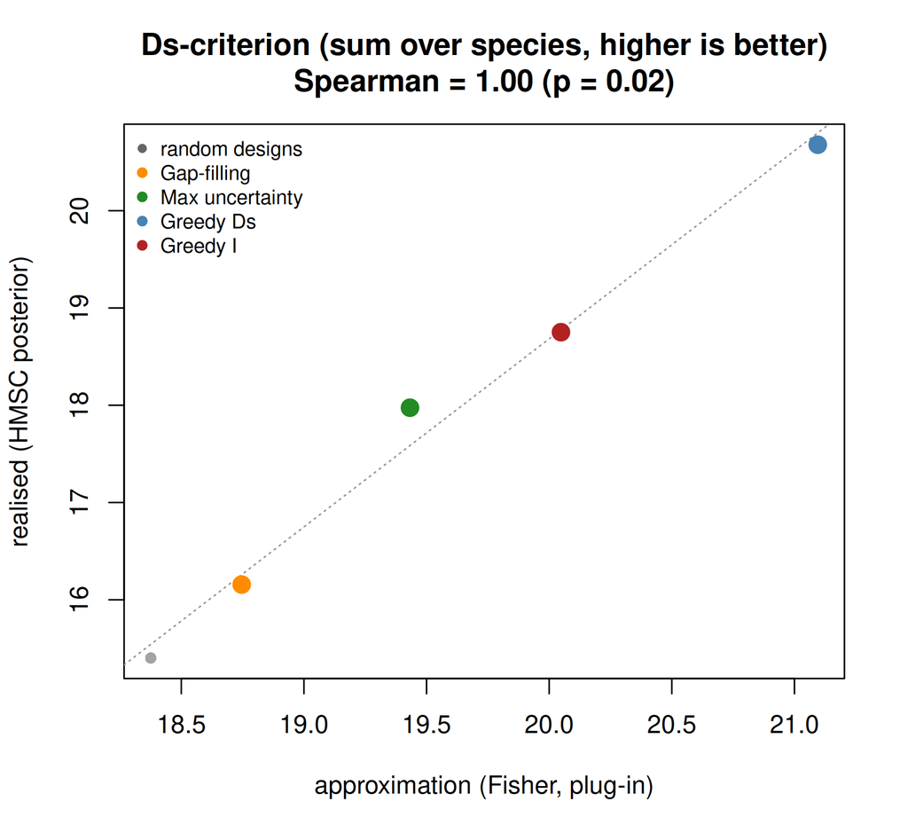

```r
scatter_cmp("Ds", "Ds-criterion (sum over species, higher is better)")
```

**I**

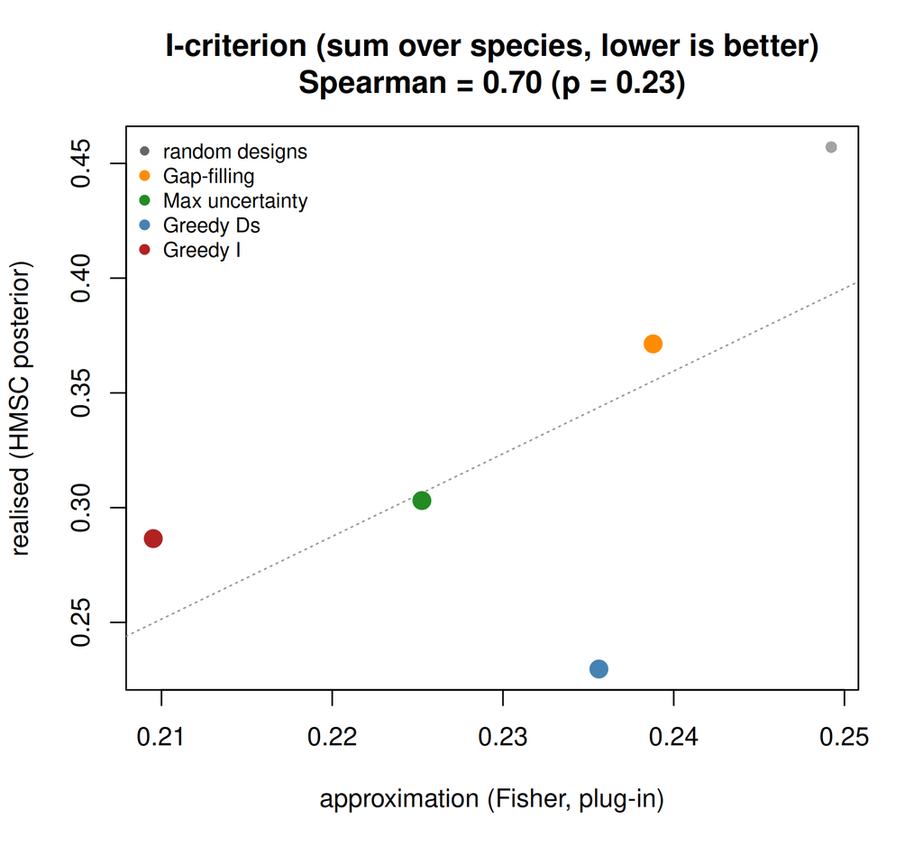

```r
scatter_cmp("I", "I-criterion (sum over species, lower is better)")
```

**SD of beta_1**

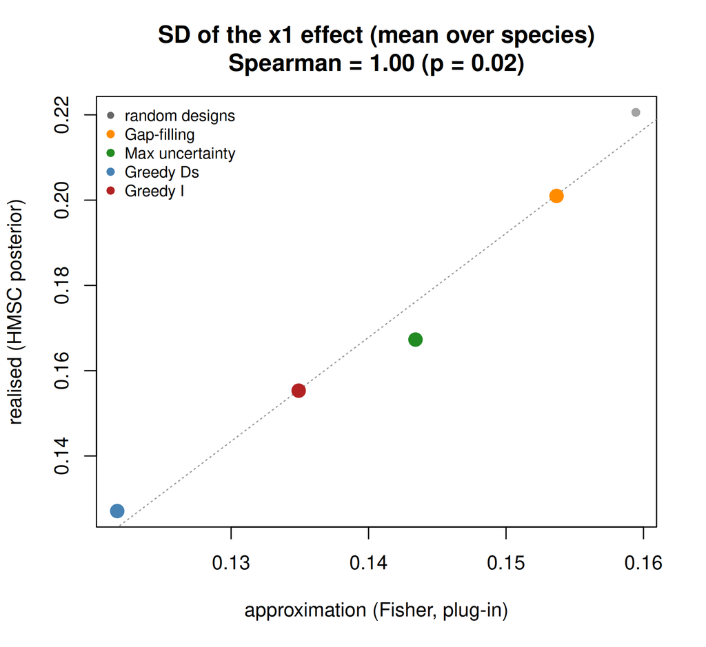

```r
scatter_cmp("sd_b1", "SD of the x1 effect (mean over species)")
```

**SD of predictions**

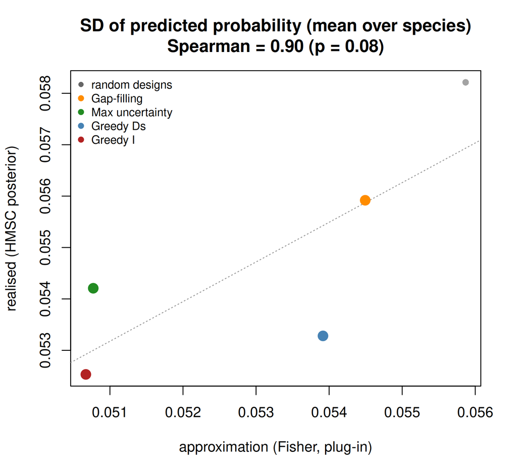

```r
scatter_cmp("sd_pred", "SD of predicted probability (mean over species)")
```

## 7.3 Is the ratio realised / approximated stable?

If the approximation is only a rescaled version of the truth, the ratio should be close to constant across designs. A large spread would mean that the approximation can mislead the choice of the design.

```r
ratio <- data.frame(
  Ds_diff = res$Ds_real - res$Ds_approx,          # difference on the log scale
  I       = res$I_real / res$I_approx,
  sd_b1   = res$sd_b1_real / res$sd_b1_approx,
  sd_pred = res$sd_pred_real / res$sd_pred_approx)
knitr::kable(
  rbind(median = sapply(ratio, median),
        min    = sapply(ratio, min),
        max    = sapply(ratio, max),
        CV     = sapply(ratio, function(v) sd(v) / abs(mean(v)))),
  digits = 3,
  col.names = c("Ds: realised - approx. (log scale)", "I: ratio", "SD b1: ratio", "SD pred.: ratio"))
```

|  | Ds: realised - approx. (log scale) | I: ratio | SD b1: ratio | SD pred.: ratio |
| --- | --- | --- | --- | --- |
| median | -1.458 | 1.367 | 1.167 | 1.037 |
| min | -2.974 | 0.975 | 1.044 | 0.988 |
| max | -0.417 | 1.834 | 1.383 | 1.068 |
| CV | 0.592 | 0.222 | 0.111 | 0.028 |

## 7.4 Is the gain over the base model predicted correctly?

This is the quantity the greedy algorithms actually maximise. For Ds the gain is $\Psi_{D_s}(\text{design}) - \Psi_{D_s}(\text{base})$ (higher is better); for I it is the **reduction** of the average prediction variance, $I(\text{base}) - I(\text{design})$ (higher is better).

```r
gain <- data.frame(
  design        = res$design,
  Ds_gain_approx = res$Ds_approx - base_row$Ds_approx,
  Ds_gain_real   = res$Ds_real   - base_row$Ds_real,
  I_gain_approx  = base_row$I_approx - res$I_approx,
  I_gain_real    = base_row$I_real   - res$I_real)
gain_tab <- rbind(
  data.frame(design = "Random (median)", t(apply(gain[grepl("^Random", gain$design), -1], 2, median))),
  gain[gain$design %in% strat, ])
knitr::kable(gain_tab, digits = 3, row.names = FALSE,
             col.names = c("Design", "Ds gain approx.", "Ds gain realised",
                           "I gain approx.", "I gain realised"))
```

| Design | Ds gain approx. | Ds gain realised | I gain approx. | I gain realised |
| --- | --- | --- | --- | --- |
| Random (median) | 1.967 | -0.812 | 0.103 | -0.083 |
| Gap-filling | 2.338 | -0.058 | 0.114 | 0.003 |
| Max uncertainty | 3.024 | 1.761 | 0.127 | 0.071 |
| Greedy Ds | 4.686 | 4.464 | 0.117 | 0.145 |
| Greedy I | 3.639 | 2.537 | 0.143 | 0.088 |

And the rank of the five “strategies” (random median + 4) under each evaluation (1 = best):

```r
rk <- gain_tab
rk_tab <- data.frame(
  design        = rk$design,
  Ds_approx     = rank(-rk$Ds_gain_approx),
  Ds_realised   = rank(-rk$Ds_gain_real),
  I_approx      = rank(-rk$I_gain_approx),
  I_realised    = rank(-rk$I_gain_real))
knitr::kable(rk_tab, row.names = FALSE,
             col.names = c("Design", "Ds (approx.)", "Ds (realised)", "I (approx.)", "I (realised)"))
```

| Design | Ds (approx.) | Ds (realised) | I (approx.) | I (realised) |
| --- | --- | --- | --- | --- |
| Random (median) | 5 | 5 | 5 | 5 |
| Gap-filling | 4 | 4 | 4 | 4 |
| Max uncertainty | 3 | 3 | 2 | 3 |
| Greedy Ds | 1 | 1 | 3 | 1 |
| Greedy I | 2 | 2 | 1 | 2 |